# Lista 5

Gabriel Mizuno

# Questao 1

$\sigma^2=25$

### a)

TH unilateral a esquerda.

$H_{0}:\mu=\mu_{0}$ vs $H_{1}:\mu<\mu_{0}$

$\alpha=P($Erro tipo I$)=P(\overline{X}<x.c)$  
**OBS:**Para calcular a probabilidade pedida estou padronizando

```r
TH.media=function(x,sigma,alfa,mi0){
  n <- length(x)
  x.barra <- mean(x)
  z <- qnorm(alfa)
  #Criando a Regiao Critica
  x.c <- mi0+sigma*z/sqrt(n)
  #Estimativas e RC
  cat("Estimativa Pontual;",x.barra,"\n","Regiao cirtica=(-inf,",x.c,"]")
  #Decidindo
  if (x.barra<x.c){
    cat("\n","Rejeita-se Ho a um nivel de significancia",alfa)
  }
  else{
    cat("\n","Nao rejeita-se Ho a um nivel de significancia",alfa)
  }
}
a <- rnorm(10,2,5)
TH.media(a,sigma=5,alfa=.1,mi0=2)
```

```
## Estimativa Pontual; 5.167044
##  Regiao cirtica=(-inf, -0.02631094 ]
##  Nao rejeita-se Ho a um nivel de significancia 0.1
```

**OBS:**Nao estou padronizando

```r
TH.media2=function(x,sigma,alfa,mi0){
  n <- length(x)
  x.barra <- mean(x)
  #Determinando a Regiao Critica
  x.c <- qnorm(p=alfa,mean=mi0,sd=sigma/sqrt(n))
  cat("Estimativa Pontual;",x.barra,"\n","Regiao cirtica=[-inf,",x.c,"]")
  #Decidindo
  if (x.barra<x.c){
    cat("\n","Rejeita-se Ho a um nivel de significancia",alfa)
  }
  else{
    cat("\n","Nao rejeita-se Ho a um nivel de significancia",alfa)
  }
}
TH.media2(a,sigma=5,alfa=.1,mi0=2)
```

```
## Estimativa Pontual; 5.167044
##  Regiao cirtica=[-inf, -0.02631094 ]
##  Nao rejeita-se Ho a um nivel de significancia 0.1
```

### b)

TH unilateral a direita.

$H_{0}:\sigma^2=\sigma^2_{0}$ vs $H_{1}:\sigma^2>\sigma^2_{0}$

$\alpha=P($Erro tipo I$)=P(Q>q.c)$, onde $Q\sim\chi_{n-1}^2$

```r
TH.var=function(x,sigma20,alfa){
  n <- length(x)
  s2 <- var(x)
  #Criando a Regiao Critica
  q.c <- qchisq(df=n-1,lower.tail=FALSE,p=alfa)
  #Estimativas e RC
  cat("Estimativa Pontual;",s2,"\n","Regiao cirtica; [",q.c,"inf)")
  #Decidindo
  q <- (n-1)*s2/sigma20
  if (q>q.c){
    cat("\n","Rejeita-se Ho a um nivel de significancia",alfa)
  }
  else{
    cat("\n","Nao rejeita-se Ho a um nivel de significancia",alfa)
  }
}
TH.var(rnorm(10),sigma20=1,alfa=.1)
```

```
## Estimativa Pontual; 1.476951
##  Regiao cirtica; [ 14.68366 inf)
##  Nao rejeita-se Ho a um nivel de significancia 0.1
```

### c)

TH Bilateral

$H_{0}:p=p_{0}$ vs $H_{1}:p\neq p_{0}$

$\alpha=P($Erro tipo I$)=P(\widehat{P}<p.c_{1}$ ou $\widehat{P}>p.c_{2})$

```r
TH.prop=function(x,h,alfa,p0){
  print(x)
  for (i in 1:length(x)){
    if (x[i]<h){
      x[i] <- 0
    }
    if (x[i]>h){
      x[i] <- 1
    }
  }
  print(x)
  n <- length(x)
  p.chapeu <- mean(x)
  #Criando a Regiao Critica
  p.c1 <- qnorm(alfa/2,mean=p0,sd=sqrt(p0*(1-p0)/n))
  p.c2 <- qnorm(1-alfa/2,mean=p0,sd=sqrt(p0*(1-p0)/n))
  #Estimativas e RC
  cat("Estimativa Pontual;",p.chapeu,"\n",
      "Regiao cirtica=(-inf;",p.c1,"]U[",p.c2,"inf)")
  #Decidindo
  if (p.chapeu>p.c1 | p.chapeu<p.c2){
    cat("\n","Rejeita-se Ho a um nivel de significancia",alfa)
  }
  else{
    cat("\n","Nao rejeita-se Ho a um nivel de significancia",alfa)
  }
}
a <- rnorm(10,10,1)
TH.prop(x=a,alfa=0.05,h=10,p0=0.3)
```

```
##  [1] 10.122918  8.306348 12.063872  8.856389 11.110331 10.413433 10.272746
##  [8]  9.859956 10.248900  8.822965
##  [1] 1 0 1 0 1 1 1 0 1 0
## Estimativa Pontual; 0.6
##  Regiao cirtica=(-inf; 0.01597423 ]U[ 0.5840258 inf)
##  Rejeita-se Ho a um nivel de significancia 0.05
```

### d)

TH unilateral a esquerda, usando a Estatistica de Teste: $Z=\frac{(\overline{X}-\mu_{0})\cdot\sqrt{n}}{\sigma}$

$H_{0}:\mu=\mu_{0}$ vs $H_{1}:\mu<\mu_{0}$

$\alpha=P($Erro tipo I$)=P(Z<z.c)$, onde Z~N(0,1)

```r
TH.media2=function(x,sigma,alfa,mi0){
  n <- length(x)
  x.barra <- mean(x)
  z <- (x.barra-mi0)*sqrt(n)/sigma
  #Criando a Regiao Critica (com base em z)
  z.c <- qnorm(alfa)
  #Estimativas e RC
  cat("Estimativa Pontual;",x.barra,"\n","Regiao cirtica=(-inf,",z.c,"]")
  #Decidindo
  if (z<z.c){
    cat("\n","Rejeita-se Ho a um nivel de significancia",alfa)
  }
  else{
    cat("\n","Nao rejeita-se Ho a um nivel de significancia",alfa)
  }
}
TH.media2(rnorm(10,mean=10,sd=5),sigma=5,alfa=.1,mi0=10)
```

```
## Estimativa Pontual; 12.52983
##  Regiao cirtica=(-inf, -1.281552 ]
##  Nao rejeita-se Ho a um nivel de significancia 0.1
```

### e)

Erro Tipo 2 unilateral a esquerda.

$H_{0}:\mu=\mu_{0}$ vs $H_{1}:\mu<\mu_{0}$

$\beta(\mu)=$$P($Nao rejeitar $H_{0}|H_{0}$ falso$)=P(\bar{X}\notin RC | \mu)=P(\bar{X}>x.c | \mu)$

```r
ET2=function(n,alfa,sigma2,mi0,mi){
  sigma <- sqrt(sigma2)
  #Criando a Regiao Critica
  z <- qnorm(alfa)
  x.c <- mi0+sigma*z/sqrt(n)
  #Calculando a probabilidade pedida
  z <- (x.c-mi)*sqrt(n)/sigma
  prob <- pnorm(z,lower.tail = FALSE)
  return(prob)
}
ET2(n=10,alfa=0.1,sigma2=25,mi0=10,mi=10)
```

```
## [1] 0.9
```

**OBS:**Para calcular a probabilidade pedida estou padronizando, porem nao e necessario fazer isso

$H_{0}:\mu=\mu_{0}$ vs $H_{1}:\mu<\mu_{0}$

$\beta(\mu)=$$P($Nao rejeitar $H_{0}|H_{0}$ falso$)=P(\bar{X}\notin RC | \mu)=P(\bar{X}>x.c | \mu)$

```r
ET2.2=function(n,alfa,sigma2,mi0,mi){
  sigma <- sqrt(sigma2)
  #Criando a Regiao Critica
  x.c <- qnorm(p=alfa,mean=mi0,sd=sigma/sqrt(n))
  #Calculando a probabilidade pedida
  prob <- pnorm(x.c,mi,sigma/sqrt(n),lower.tail=FALSE)
  return(prob)
}
ET2.2(n=10,alfa=0.1,sigma2=25,mi0=10,mi=5)
```

```
## [1] 0.03000459
```

### f)

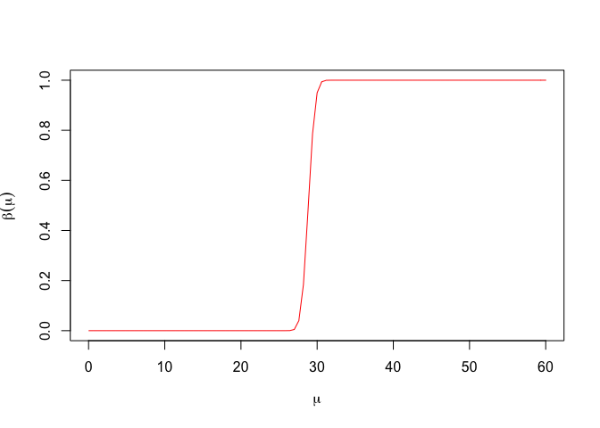

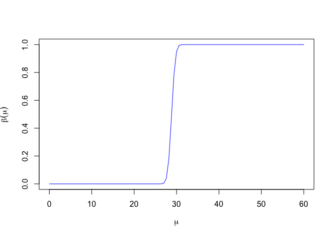

### g)

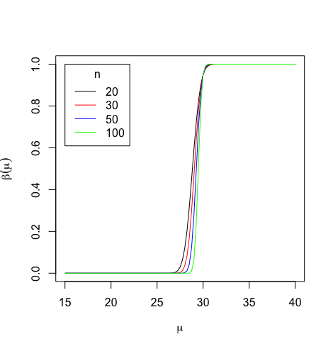

```r
curve(ET2(n=20,alfa=0.05,mi0=30,sigma2=10,x),15,40,add=TRUE
      ,ylab=expression(beta(mu)),xlab=expression(mu))
curve(ET2(n=30,alfa=0.05,mi0=30,sigma2=10,x),15,40,add=TRUE,col="red"
      ,ylab=expression(beta(mu)),xlab=expression(mu))
curve(ET2(n=50,alfa=0.05,mi0=30,sigma2=10,x),15,40,add=TRUE,col="blue"
      ,ylab=expression(beta(mu)),xlab=expression(mu))
curve(ET2(n=100,alfa=0.05,mi0=30,sigma2=10,x),15,40,add=TRUE,col="green"
      ,ylab=expression(beta(mu)),xlab=expression(mu))
legend(15, 1,
       c("20", "30", "50", "100"), title="n",
       col=c("black", "red","blue","green"),
       lty=c(1, 1))
```

### h)

Funcao Poder para TH Bilateral.

$H_{0}:\mu=\mu_{0}$ vs $H_{1}:\mu\neq \mu_{0}$

$\pi(\mu)=P($Rejeitar $H_{0}|\mu)=P(\bar{X}\in RC|\mu)=P(\bar{X}>x.c_{1}$ ou $\bar{X}<x.c_{2}|\mu)$

```r
poderBi=function(n,alfa,sigma2,mi0,mi){
  sigma <- sqrt(sigma2)
  #achando a regiao critica
  x.c1 <- qnorm(1-alfa/2,mean=mi0,sd=sqrt(sigma2/n))
  x.c2 <- qnorm(alfa/2,mean=mi0,sd=sqrt(sigma2/n))
  #funcao poder
  poder <- pnorm(x.c2,mean=mi,sd=sqrt(sigma2/n))+pnorm(x.c1,mean=mi,sd=sqrt(sigma2/n)
                                                       ,lower.tail=FALSE)
  return(poder)
}
poderBi(n=10,alfa=0.05,sigma2=25,mi0=10,mi=10)
```

```
## [1] 0.05
```

### i)

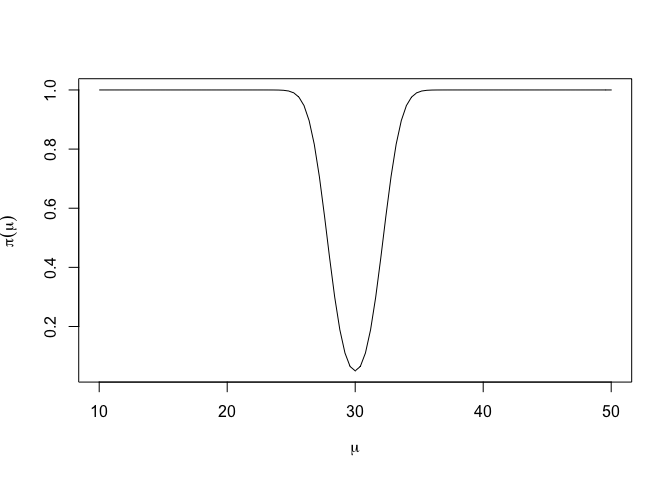

### j)

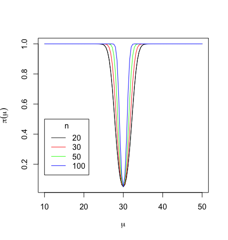

```r
curve(poderBi(n=20,alfa=0.05,x,sigma2=25,mi0=30),10,50,add=TRUE
      ,ylab=expression(pi(mu)),xlab=expression(mu))
curve(poderBi(n=30,alfa=0.05,x,sigma2=25,mi0=30),10,50,add=TRUE,col="red"
      ,ylab=expression(pi(mu)),xlab=expression(mu))
curve(poderBi(n=50,alfa=0.05,x,sigma2=25,mi0=30),10,50,add=TRUE,col="green"
      ,ylab=expression(pi(mu)),xlab=expression(mu))
curve(poderBi(n=100,alfa=0.05,x,sigma2=25,mi0=30),10,50,add=TRUE,col="blue"
      ,ylab=expression(pi(mu)),xlab=expression(mu))
legend(10,0.5,
       c("20", "30", "50", "100"), title="n",
       col=c("black", "red","green","blue"),
       lty=c(1, 1))
```

# Questao 2

### a)

TH unilateral a direita para media com variancia desconhecida.

$H_{0}:\mu=\mu_{0}$ vs $H_{1}:\mu > \mu_{0}$

$\alpha=P($Erro tipo I$)=P(\overline{X}>t.c | \mu=\mu_{0})$

```r
TH.media=function(x,alfa,mi0){
  n <- length(x)
  x.barra <- mean(x)
  s <- sd(x)
  #Criando a Regiao Critica
  t <- qt(p=1-alfa,df=n-1)
  t.c <- mi0+t*s/sqrt(n)
  cat("Estimativa Pontual;",s^2,"\n","Regiao Critica;[",t.c,";Inf)")
  #Decidindo
  if (x.barra>t.c){
    cat("\n","Rejeita-se Ho a um nivel de significancia",alfa)
  }
  else{
    cat("\n","Nao rejeita-se Ho a um nivel de significancia",alfa)
  }
}
```

### b)

TH unilateral a direita para media com variancia desconhecida.

$H_{0}:\mu=\mu_{0}$ vs $H_{1}:\mu > \mu_{0}$

Usando a Estatistica de Teste: $T=\frac{(\overline{X}-\mu_{0})\cdot\sqrt{n}}{S}$ e $T\sim t_{n-1}$  
$\alpha=P($Erro tipo I$)=P(T\in R.C |\mu=\mu_{0})=P(T>z.c|\mu=\mu_{0})$

```r
TH.media2=function(x,alfa,mi0){
  n <- length(x)
  x.barra <- mean(x)
  s <- sd(x)
  z <- (x.barra-mi0)*sqrt(n)/s
  #Criando a Regiao Critica
  z.c <- qnorm(alfa)
  #Decidindo
  if (z>z.c){
    cat("Rejeita-se Ho a um nivel de significancia",alfa)
  }
  else{
    cat("Nao rejeita-se Ho a um nivel de significancia",alfa)
  }
}
```

### c)

Erro Tipo 2 para TH unilateral a direita.

$H_{0}:\mu=\mu_{0}$ vs $H_{1}:\mu > \mu_{0}$

$\beta(\mu)=P($Nao rejeitar $H_{0}|H_{0}$ e falso$)=P(\bar{X}\notin RC | \mu=\mu_{0})=P(\bar{X}<t.c | \mu=\mu_{0})$

```r
ET2=function(n,s,alfa,mi0,mi){
  #Criando a Regiao Critica
  t <- qt(p=1-alfa,df=n-1)
  t.c <- mi0+t*s/sqrt(n)
  #Calculando a probabilidade pedida(estou "padronizando")
  q <- (t.c-mi)*sqrt(n)/s
  prob <- pt(q,df=n-1)
  return(prob)
}
ET2(n=10,s=1,alfa=0.2,mi0=10,mi=10)
```

```
## [1] 0.8
```

### d)

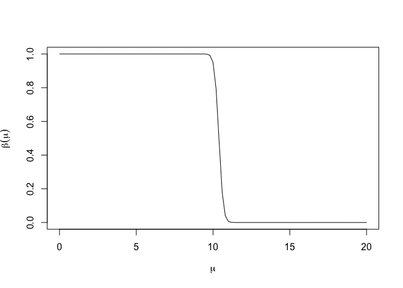

### e)

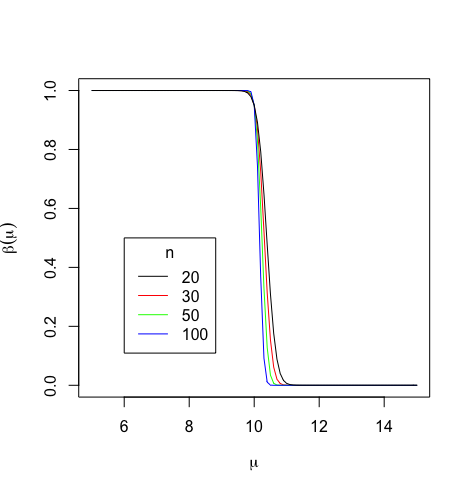

```r
curve(ET2(x,mi0=10,s=1,alfa=0.05,n=20),5,15,add=TRUE
      ,ylab=expression(beta(mu)),xlab=expression(mu))
curve(ET2(x,mi0=10,s=1,alfa=0.05,n=30),5,15,col="red",add=TRUE
      ,ylab=expression(beta(mu)),xlab=expression(mu))
curve(ET2(x,mi0=10,s=1,alfa=0.05,n=50),5,15,col="green",add=TRUE
      ,ylab=expression(beta(mu)),xlab=expression(mu))
curve(ET2(x,mi0=10,s=1,alfa=0.05,n=100),5,15,col="blue",add=TRUE
      ,ylab=expression(beta(mu)),xlab=expression(mu))
legend(6, 0.5,
       c("20", "30", "50", "100"), title="n",
       col=c("black", "red","green","blue"),
       lty=c(1, 1))
```

### f)

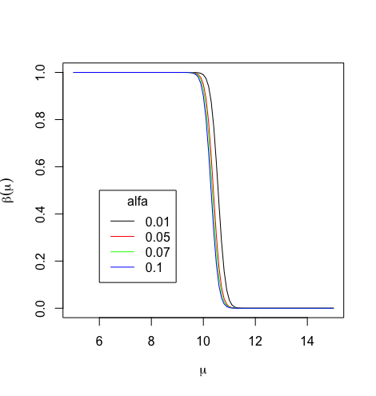

```r
curve(ET2(x,mi0=10,s=1,alfa=0.01,n=20),5,15,add=TRUE,ylab=expression(beta(mu))
      ,xlab=expression(mu))
curve(ET2(x,mi0=10,s=1,alfa=0.05,n=20),5,15,col="red",add=TRUE
      ,ylab=expression(beta(mu)),xlab=expression(mu))
curve(ET2(x,mi0=10,s=1,alfa=0.07,n=20),5,15,col="green",add=TRUE
      ,ylab=expression(beta(mu)),xlab=expression(mu))
curve(ET2(x,mi0=10,s=1,alfa=0.1,n=20),5,15,col="blue",add=TRUE
      ,ylab=expression(beta(mu)),xlab=expression(mu))
legend(6, 0.5,
      c("0.01", "0.05", "0.07", "0.1"), title=expression(alfa),
      col=c("black", "red","green","blue"),
      lty=c(1, 1))
```

### g)

Funcao Poder para TH unilateral de direita.

$H_{0}:\mu=\mu_{0}$ vs $H_{1}:\mu > \mu_{0}$

$\pi(\mu)=P($Rejeitar $H_{0}|\mu)=P(\bar{X}\in RC|\mu=\mu_{0})=P(\bar{X}>x.c_{1}|\mu=\mu_{0})$

```r
poderUni=function(n,s,alfa,mi0,mi){
  z <- qt(df=n-1,p=1-alfa)
  #Definindo a regiao critica
  t.c <- s*z/sqrt(n)+mi0
  #Calcullando a probabilidade pedida
  p <- (t.c-mi)*sqrt(n)/s
  prob <- pt(df=n-1,p,lower.tail=FALSE)
  return(prob)
}
poderUni(n=10,s=1,alfa=.05,mi0=10,mi=10)
```

```
## [1] 0.05
```

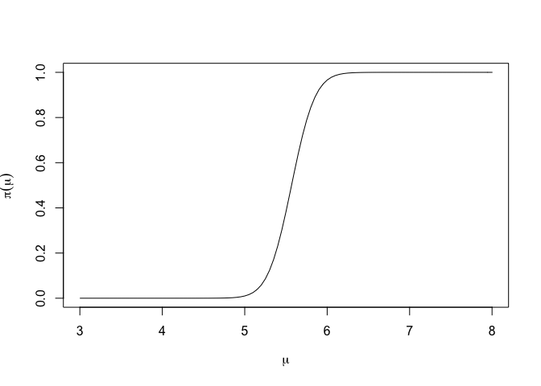

# Questao 3

```r
base=readRDS("BaseGenero.rds")
```

### a)

P-Valor$=P(\bar{X}>x|\mu=\mu_{0})$

```r
pvalorDir=function(x,alfa,mi0){
  s <- sd(x)
  x.barra <- mean(x)
  n <- length(x)
  #Calculando o p-valor
  p <- (x.barra-mi0)*sqrt(n)/s
  prob <- pt(df=n-1,p,lower.tail=FALSE)
  cat("O p-valor e:",prob,"\n")
  #Determinando se rejeita ou nao
  if (prob>alfa){
    cat("Nao rejeito a hipotese nula
        ,ou seja,a media dos peso e inferior ou igual a 70Kg")
  }
  else if (alfa>prob){
    cat("Rejeito a hipotese nula
        ,ou seja,a media dos peso e superior a 70Kg")
  }
}
base1 <- base %>% filter(Sexo=="Homem")
pvalorDir(x=base1$Peso,alfa=0.02,mi0=70)
```

```
## O p-valor e: 1.053431e-12
## Rejeito a hipotese nula
##         ,ou seja,a media dos peso e superior a 70Kg
```

**Determinando a Regiao Critica**

```r
TH.mediaDir=function(x,alfa,mi0){
  n <- length(na.omit(x))
  s <- sd(x,na.rm=TRUE)
  x.barra <- mean(x,na.rm=TRUE)
  #Determinando a Regiao Critica
  t <- qnorm(p=1-alfa)
  t.c <- s*t/sqrt(n)+mi0
  #Decidindo
  if (x.barra>t.c){
    cat("\n","Rejeita-se Ho a um nivel de significancia",alfa,"\n",
        ",ou seja,a media dos peso e superior a 70Kg")
  }
  else if (x.barra<t.c){
    cat("\n","Nao rejeita-se Ho a um nivel de significancia",alfa,"\n",
        ",ou seja,a media dos peso e inferior ou igual a 70Kg")
  }
}
base1 <- base %>% filter(Sexo=="Homem")
TH.mediaDir(x=base1$Peso,alfa=0.02,mi0=70)
```

```
##
##  Rejeita-se Ho a um nivel de significancia 0.02
##  ,ou seja,a media dos peso e superior a 70Kg
```

### b)

$H_{0}:\mu=\mu_{0}$ vs $H_{1}:\mu<\mu_{0}$ e $\alpha=0.01$

$\alpha=P($Erro tipo I$)=P(\overline{X}<t.c$ | $\mu=\mu_{0})$

```r
TH.mediaEsq=function(x,alfa,mi0){
  x.barra <-mean(x)
  n <- length(x)
  s <- sd(x)
  q <- qt(df=n-1,alfa)
  #Achando a Regiao Critica
  t.c <- mi0+q*s/sqrt(n)
  cat("Regiao cirtica=[-inf,",t.c,"]")
  #Determinando se rejeita ou nao
  if (x.barra>t.c){
    cat("\n","Nao rejeito a hipotese nula
        ,ou seja,a media de idade e superior a 30 anos ou mais")
  }
  if (x.barra<t.c){
    cat("\n","Rejeito a hipotese nula
        ,ou seja,a media de idade e inferior a 30 anos")
  }
}
base1 <- base %>% filter(Sexo=="Homem")
TH.mediaEsq(x=base1$Idade,alfa=0.01,mi0=30)
```

```
## Regiao cirtica=[-inf, 27.73446 ]
##  Nao rejeito a hipotese nula
##         ,ou seja,a media de idade e superior a 30 anos ou mais
```

**Calculando o P-Valor**  
$P-Valor=P($Erro tipo I$)=P(\overline{X}<x_{1}$ | $\mu=\mu_{0})$

```r
pvalor=function(x,alfa,mi0){
  n <- length(x)
  x1 <- mean(x,na.rm=TRUE)
  s <- sd(x,na.rm=TRUE)
  t <- (x1-mi0)*sqrt(n)/s
  pv <- pt(q=t,df=n-1)
  cat("p-valor e:",pv,"\n")
  if (alfa>pv){
    cat("Rejeitamos Ho, para im nivel de significancia:",alfa)
  }
  else if (alfa<pv){
    cat("Nao rejeitamos Ho, para im nivel de significancia:",alfa)
  }
}
pvalor(x=base1$Idade,alfa=0.01,mi0=30)
```

```
## p-valor e: 0.4653025
## Nao rejeitamos Ho, para im nivel de significancia: 0.01
```

### c)

$H_{0}:\mu=\mu_{0}$ vs $H_{1}:\mu\neq\mu_{0}$ e $\alpha=0.03$

P-Valor$=2\cdot P(\overline{X}>x|\mu=\mu_{0})$

```r
pvalorBi=function(x,alfa,mi0){
  s <- sd(x)
  x.barra <- mean(x)
  n <- length(x)
  #Calculando o p-valor(TEM Q TOMAR CUIDADO
  #POIS NAO SABEMOS "ONDE" O VALOR DE X.BARRA ESTA
  #ANTES DE COMECAR A FAZER AS CONTAS)
  if (x.barra>mi0){
    p <- (x.barra-mi0)*sqrt(n)/s
    prob <- 2*pt(df=n-1,p,lower.tail=FALSE)
    cat("O p-valor e:",prob,"\n")
  }
  else{
    p <- (x.barra-mi0)*sqrt(n)/s
    prob <- 2*pt(df=n-1,p)
    cat("O p-valor e:",prob,"\n")
  }
  #Determinando se rejeita ou nao
  if (prob>alfa){
    cat("Nao rejeito a hipotese nula
        ,ou seja,a media dos peso e inferior ou igual a 70Kg")
  }
  else if (alfa>prob){
    cat("Rejeito a hipotese nula
        ,ou seja,a media dos peso e superior a 70Kg")
  }
}
base1<-filter(base,base$Sexo=="Mulher")
pvalorBi(x=base1$Idade,alfa=0.03,mi0=20)
```

[output not shown]

**Determinando a Regiao Critica**

```r
TH.mediaDif=function(x,alfa,mi0){
  n <- length(x)
  x.barra <- mean(x,na.rm=TRUE)
  s <- sd(x,na.rm=TRUE)
  t1 <- qt(p=alfa/2,df=n-1)
  t2 <- qt(p=1-alfa/2,df=n-1)
  #Determinando a Regiao Critica
  t.c1 <- s*t1/sqrt(n)+mi0
  t.c2 <- s*t2/sqrt(n)+mi0
  #Decidindo
  if (x.barra<t.c1 | x.barra>t.c2 ){
    cat("\n","Rejeita-se Ho a um nivel de significancia",alfa,"\n",
        ",ou seja,a media das idades e diferente a 20 anos")
  }
  else{
    cat("\n","Nao rejeita-se Ho a um nivel de significancia",alfa,"\n",
        ",ou seja,a media dos peso e igual a 20 anos")
  }
}
base1<-filter(base,base$Sexo=="Mulher")
TH.mediaDif(x=base1$Idade,alfa=0.03,mi0=20)
```

```
##
##  Rejeita-se Ho a um nivel de significancia 0.03
##  ,ou seja,a media das idades e diferente a 20 anos
```

### d)

$H_{0}:p=p_{0}$ vs $H_{1}:p>p_{0}$

$\alpha=P($Erro tipo I$)=P(\widehat{P}\in R.C|p=p_{0})=P(\widehat{P}>p.c)$

```r
TH.prop=function(x,alfa,h,p0){
  print(x)
  #Determinando a proporcao observada
  for (i in 1:length(x)){
    x[i] <- ifelse(x[i]>h,1,0)
  }
  print(x)
  p1 <- mean(x)
  n <- length(x)
  q <- qnorm(p=1-alfa)
  #Achando a Regiao Critica
  p.c <- p0+q*sqrt(p0*(1-p0))/sqrt(n)
  #Determinando se rejeita ou nao
  cat("Valor observado:",p1,"\n","Regiao cirtica=[",p.c,":1]","\n")
  if (p1>p.c){
    cat("Rejeito a hipotese nula
        ,ou seja,a media dos peso e superior a 70Kg")
  }
  else if (p1<p.c){
    cat("Nao rejeito a hipotese nula,
        ou seja,a media dos peso e inferior ou igual a 70Kg")
  }}
base1 <- base %>% filter(Sexo=="Mulher")
TH.prop(x=base1$Peso,alfa=0.05,p0=0.65,h=70)
```

```
##  [1] 55 70 49 49 75 70 67 70 75 49 70 55 75 75 75 49 55 49 49 55
##  [1] 0 0 0 0 1 0 0 0 1 0 0 0 1 1 1 0 0 0 0 0
## Valor observado: 0.25
##  Regiao cirtica=[ 0.8254296 :1]
## Nao rejeito a hipotese nula,
##         ou seja,a media dos peso e inferior ou igual a 70Kg
```

**Outra ideia para resolver a questao**

```r
TH.prop2=function(x,alfa,p0,h){
  #Determinando a proporcao observada.
  y <- ifelse(x>h,1,0)
  p1 <- mean(y)
  n <- length(y)
  #Achando a Regiao Critica.
  p.c <- qnorm(p=1-alfa,mean=p0,sd=sqrt(p0*(1-p0))/sqrt(n))
  #Determinando se rejeita ou nao.
  cat("Valor observado:",p1,"\n","Regiao cirtica=[",p.c,":1]","\n")
  if (p1>p.c){
    cat("Rejeito a hipotese nula,ou seja,a media dos peso e superior a 70Kg")
  }
  else if (p1<p.c){
    cat("Nao rejeito a hipotese nula,ou seja,a media dos peso
        e inferior ou igual a 70Kg")
  }
}
base1 <- base %>% filter(Sexo=="Mulher")
TH.prop2(x=base1$Peso,alfa=0.05,p0=0.65,h=70)
```

```
## Valor observado: 0.25
##  Regiao cirtica=[ 0.8254296 :1]
## Nao rejeito a hipotese nula,ou seja,a media dos peso
##         e inferior ou igual a 70Kg
```

**Calculando o P-Valor**

```r
pvalor=function(x,alfa,h,p0){
  y <- ifelse(x>h,1,0)
  p1 <- mean(y)
  n <- length(y)
  #Calculando o p-valor.
  pv <- pnorm(q=p1,mean=p0,sd=sqrt(p0*(1-p0)/n),lower.tail=FALSE)
  cat("p-valor e:",pv,"\n")
  #Determinando se rejeito ou nao.
  if (alfa>pv){
    cat("Rejeitamos Ho, para im nivel de significancia:",alfa)
  }
  else if (alfa<pv){
    cat("Nao rejeitamos Ho, para im nivel de significancia:",alfa)
  }
}
pvalor(x=base1$Peso,p0=0.65,h=70,alfa=0.05)
```

```
## p-valor e: 0.9999117
## Nao rejeitamos Ho, para im nivel de significancia: 0.05
```

Note que para qualquer nivel de significancia aceitavel temos que p-valor>alfa ,ou seja, nao reijeitamos a hipotese nula para qualquer nivel de significancia aceitavel

# Questao 4

### a)

```r
base1 <- base %>% filter(Sexo=="Homem")
t.test(base1$Peso, alternative = "greater", mu = 70,conf.level=0.95)
```

```
##
##  One Sample t-test
##
## data:  base1$Peso
## t = 13.065, df = 24, p-value = 1.053e-12
## alternative hypothesis: true mean is greater than 70
## 95 percent confidence interval:
##  79.60978      Inf
## sample estimates:
## mean of x
##  81.05778
```

```r
#Como alfa e maior que p-valor rejeitamos Ho,ou seja
#, ha evidencias que a media dos pesos e maior que 70Kg
```

Outra ideia para resolver a questao usando funcoes do R

```r
base1 <- base %>% filter(Sexo=="Homem")
valor=function(alfa){
  conf <- 1-alfa
  p <- t.test(base1$Peso, alternative = "greater", mu = 70,conf.level=0.95)[[3]]
  cat("P-valor e:",p,"\n")
  if (p>alfa){
    cat("Como p-valor e maior do que alfa nao rejeitamos Ho
        ,ou seja, ha evidencias que a media das idades e maior ou igual que 70 Kg")
  }
  else if (p<alfa){
    cat("Como p-valor e menor do que alfar rejeitamos Ho
        ,ou seja, ha evidencias que a media das idades e menor que 70 Kg")
  }
}
```

### b)

```r
base1 <- base %>% filter(Sexo=="Homem")
t.test(base1$Idade, alternative = "less", mu = 30,conf.level=0.99)
```

```
##
##  One Sample t-test
##
## data:  base1$Idade
## t = -0.088002, df = 24, p-value = 0.4653
## alternative hypothesis: true mean is less than 30
## 99 percent confidence interval:
##      -Inf 32.18554
## sample estimates:
## mean of x
##     29.92
```

```r
#Como alfa e menor que p-valor nao rejeitamos Ho
#,ou seja, ha evidencias que a media das idades e maior ou igual que 30 anos
```

Outra ideia para resolver a questao usando funcoes do R

```r
base2 <- base %>% filter(Sexo=="Homem")
valor=function(alfa){
  conf <- 1-alfa
  p <- t.test(base2$Idade, alternative = "less", mu = 30,conf.level=conf)[[3]]
  cat("P-valor e:",p,"\n")
  if (p>alfa){
    cat("Como p-valor e maior do que alfa nao rejeitamos Ho
        ,ou seja, ha evidencias que a media das idades e maior ou igual que 30 anos")
  }
  else if (p<alfa){
    cat("Como p-valor e menor do que alfar rejeitamos Ho
        ,ou seja, ha evidencias que a media das idades e menor que 30 anos")
  }
}
valor(alfa=0.01)
```

```
## P-valor e: 0.4653025
## Como p-valor e maior do que alfa nao rejeitamos Ho
##         ,ou seja, ha evidencias que a media das idades e maior ou igual que 30 anos
```

### c)

```r
base3 <- base %>% filter(Sexo=="Mulher")
t.test(base3$Idade,alternative="two.sided",conf.level=0.97,mu=20)
```

```
##
##  One Sample t-test
##
## data:  base3$Idade
## t = 6.5822, df = 19, p-value = 2.667e-06
## alternative hypothesis: true mean is not equal to 20
## 97 percent confidence interval:
##  23.37908 27.12092
## sample estimates:
## mean of x
##     25.25
```

```r
#Como alfa e maior que p-valor rejeitamos Ho
#,ou seja, ha evidencias que a media das idades e diferente de 20 anos
```

Outra ideia para resolver a questao usando funcoes do R

```r
base3 <- base %>% filter(Sexo=="Mulher")
valor=function(alfa){
  conf <- 1-alfa
  p <- t.test(base3$Idade,alternative="two.sided",conf.level=0.97,mu=20)[[3]]
  cat("P-valor e:",p,"\n")
  if (p>alfa){
    cat("Como p-valor e maior do que alfa nao rejeitamos Ho
        ,ou seja, ha evidencias que a media das idades e maior ou igual que 30 anos")
  }
  else if (p<alfa){
    cat("Como p-valor e menor do que alfar rejeitamos Ho
        ,ou seja, ha evidencias que a media das idades e difentente de 20 anos")
  }
}
valor(alfa=0.01)
```

```
## P-valor e: 2.666996e-06
## Como p-valor e menor do que alfar rejeitamos Ho
##         ,ou seja, ha evidencias que a media das idades e difentente de 20 anos
```

### d)

```r
base1 <- base %>% filter(Sexo=="Mulher")
proporcao <- ifelse(base1$Peso>70,1,0)
prop.test(sum(proporcao), length(proporcao), alternative = "greater", p = 0.65, correct = FALSE,conf.level=0.95)
```

```
##
##  1-sample proportions test without continuity correction
##
## data:  sum(proporcao) out of length(proporcao), null probability 0.65
## X-squared = 14.066, df = 1, p-value = 0.9999
## alternative hypothesis: true p is greater than 0.65
## 95 percent confidence interval:
##  0.1273772 1.0000000
## sample estimates:
##    p
## 0.25
```

```r
#Para qualquer nivel de significancia aceitavel temos que p-valor>alfa
#,ou seja, nao reijeitamos a hipotese nula para qualquer nivel de significancia
#aceitavel
```

Outra ideia para resolver a questao usando funcoes do R

```r
base4 <- base %>% filter(Sexo=="Mulher")
valor=function(alfa){
  conf <- 1-alfa
  p <- t.test(base4$Idade,alternative="two.sided",conf.level=0.97,mu=20)[[3]]
  cat("P-valor e:",p,"\n")
  cat("Para qualquer nivel de significancia aceitavel temos que p-valor>alfa
      ou seja, nao reijeitamos a hipotese nula para qualquer nivel de significancia
      aceitavel")
}
valor(alfa=0.01)
```

[output not shown]

# Questao 5

Erro Tipo 2 para TH unilateral a direita para proporcao.

$H_{0}:p=p_{0}$ vs $H_{1}:p>p_{0}$

```r
ET2prop=function(x,alfa,p0,p){
  n <- length(x)
  #Determinando a Regiao Critica.
  z <- qnorm(1-alfa)
  p.c <- p0+sqrt(p0*(1-p0))*z/sqrt(n)
  #Determinando a prob do erro tipo II.
  p <- (p.c-p)*sqrt(n)/sqrt(p*(1-p))
  prob <- pnorm(p)
  cat("Probabilidade de erro tipo II e;",prob)
}
a <- rnorm(20)
ET2prop(x=a,alfa=0.05,p0=0.5,p=0.5)
```

```
## Probabilidade de erro tipo II e; 0.95
```

```r
ET2prop(x=a,alfa=0.1,p0=0.3,p=0.3)
```

```
## Probabilidade de erro tipo II e; 0.9
```

# Questao 6

Funcao Poder para TH bilateral para proporcao.

$H_{0}:p=p_{0}$ vs $H_{1}:p\neq p_{0}$

$\pi(p)=P(\widehat{P}\in R.C |p)=P(\widehat{P}>p.c_{1}$ ou $\widehat{P}<p.c_{2}$ $|p)=P(\widehat{P}>p.c_{1}|p)+P(\widehat{P}<p.c_{2}|p)$

```r
PoderBi=function(x,alfa,p0,p){
  n <- length(x)
  #Determinando a Regiao Critica
  z1 <- qnorm(1-alfa/2)
  z2 <- qnorm(alfa/2)
  p <- ifelse(p>=0&p<=1,p,1)
  p.c1 <-p0+sqrt(p0*(1-p0)/n)*z1
  p.c2 <-p0+sqrt(p0*(1-p0)/n)*z2
  #Achando a funcao poder
  p1 <- pnorm(p.c2,mean=p,sd=sqrt(p*(1-p)/n))
  p2 <- pnorm(p.c1,mean=p,sd=sqrt(p*(1-p)/n),lower.tail=F)
  prob <- p1+p2
  return(prob)
}
```

[output not shown]

[output not shown]

[figure not shown]